# Google Data Analytics certificate Case project: Amazon Top 50 Bestselling Books 2009 - 2019

Fernando A. Scelzo

2022-06-19

## Introduction

This is my analysis of the data set on Amazon’s Top 50 bestselling books from 2009 to 2019[^1], scrapped on October 2020. It contains 550 books, the data has been categorized into fiction and non-fiction.

As the data was limited in some aspects, e.g. genre, the original data set was combined with a Goodreads Books data set[^2] to include other specific genres, and number of pages. Other information was discarded.

### Tools and methodology.

The data sets (in .csv format) were cleaned using Google’s Spreadsheets, and merged using SQL through Google’s Big Query, for marching book titles. While Amazon (AMZ) data set is divided into genre vs. fiction, Goodreads books (GR) data set includes more specific genres, raked according to users’ votes, so the main specific genre was extracted based on maximum number of votes.

Some missing page numbers were added, by searching directly on Amazon’s website. Similarly, price 0 entries were corrected - it was assumed price belonged to eBooks, so the printed version was chosen.

Repeated entries in the AMZ set were left, as they correspond to the book being in the Top 50 in different years. Contrarily, duplicates in the GR set correspond to different editions, so their values were averaged. All column names were lower-cased. The new table was thus:

```
  * amazon.Name as title: Name of the book
  * amazon.Author as author: The author of the Book
  * amazon.User_Rating as amz_rating: Amazon User Rating
  * amazon.Reviews as amz_reviews: Number of written reviews on Amazon
  * Average of goodreads.average_rating as gr_rating: Goodreads Books User Rating
  * Average of goodreads.review_count as gr_reviews: Number of written reviews on Goodreads Books
  * amazon.Price as price: The price of the book (As at 13/10/2020)
  * amazon.Year as year: The Year(s) it ranked on Amazon's bestseller list
  * amazon.Genre as genre: Whether fiction or non-fiction
  * goodreads.genre as gr_genre: Specific genres, as voted by Goodreads Books Users
  * goodreads.number_of_pages as num_pages: Number of pages
```

### SQL Queries:

- Deleted GR duplicates choosing genre based on max votes:

  ```
  WITH trimmed_gr AS (SELECT DISTINCT title as new_title,
  MAX(SAFE_CAST(votes as INT)) as max_votes -- Removes duplicates, choosing genre based on max votes

  FROM
  `amazon_books.goodreads` GROUP BY title)

  SELECT
  *

  FROM
  amazon_books.goodreads as goodreads
  INNER JOIN trimmed_gr
  ON goodreads.title = trimmed_gr.new_title
  WHERE SAFE_CAST(goodreads.votes as INT) = trimmed_gr.max_votes
  ORDER BY title
  ```

- Data sets merged (INNER JOIN):

  ```
  SELECT
  amazon.Name as title,
  amazon.Author as author,
  AVG(amazon.User_Rating) as amz_rating,
  AVG(amazon.Reviews) as amz_reviews,
  AVG(goodreads.average_rating) as gr_rating,
  AVG(goodreads.review_count) as gr_reviews,
  AVG(amazon.Price) as price,
  amazon.Year, amazon.Genre,
  goodreads.genre,
  AVG(SAFE_CAST(goodreads.number_of_pages as INT)) as num_pages,

  FROM
  `amazon_books.bestsellers` as amazon
  INNER JOIN
  `amazon_books.goodreads_trimmed` as goodreads
  ON amazon.Name = goodreads.title

  GROUP BY
  amazon.Name,
  amazon.Author,
  amazon.Year,
  amazon.Genre,
  goodreads.genre

  ORDER BY
  amazon.Name
  ```

## Analysis

The new (merged) data set thus contains the following columns:

```r
colnames(amazon_goodreads_merged)
```

```
##  [1] "title"       "author"      "amz_rating"  "amz_reviews" "gr_rating"
##  [6] "gr_reviews"  "price"       "year"        "genre"       "gr_genre"
## [11] "num_pages"
```

### Starting questions:

- What are the most popular books and authors for the years 2009-2019?
- Do average user ratings vary with time, or by genre, etc?
- Are AMZ ratings different to GR’s?
- Is there any relation between book price or number of pages and book rating?
- What’s the average price? Has it changed over time?

## Most popular books

### Number of times a book has been in the Top 50

```
## # A tibble: 10 × 3
## # Groups:   title [10]
##    title                                                       amz_reviews count
##    <chr>                                                             <dbl> <int>
##  1 Oh, the Places You'll Go!                                         21834     8
##  2 The Very Hungry Caterpillar                                       19546     7
##  3 The 5 Love Languages: The Secret to Love that Lasts               25554     5
##  4 The Five Dysfunctions of a Team: A Leadership Fable                3207     5
##  5 To Kill a Mockingbird                                             26234     5
##  6 Wonder                                                            21625     5
##  7 The 7 Habits of Highly Effective People: Powerful Lessons …        9325     4
##  8 The Life-Changing Magic of Tidying Up: The Japanese Art of…       22641     4
##  9 You Are a Badass: How to Stop Doubting Your Greatness and …       14331     4
## 10 Crazy Love: Overwhelmed by a Relentless God                        1542     3
```

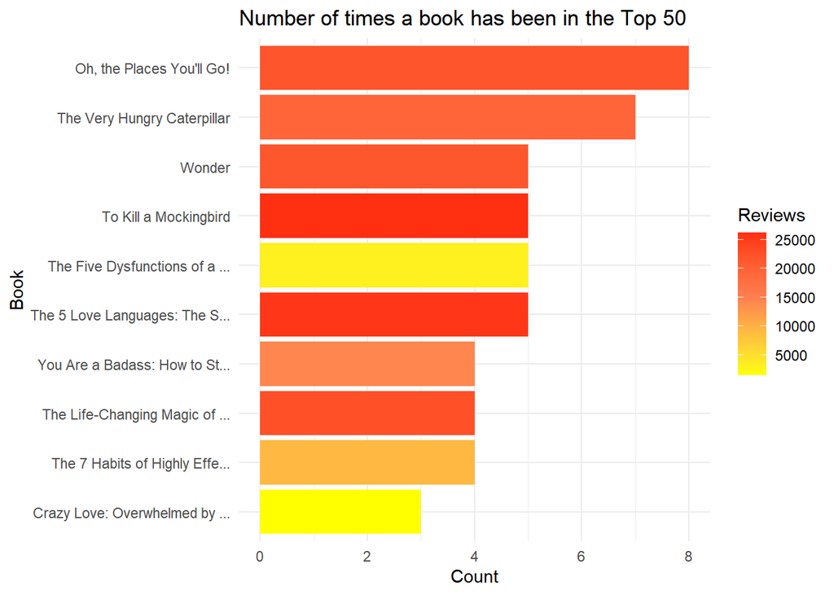

## Most popular authors

### Number of times an author has been in the Top 50, by genre

```
## # A tibble: 10 × 3
## # Groups:   author [10]
##    author           genre       count
##    <chr>            <chr>       <int>
##  1 Dr. Seuss        Fiction         8
##  2 Eric Carle       Fiction         7
##  3 Stephen R. Covey Non Fiction     7
##  4 Gary Chapman     Non Fiction     5
##  5 Harper Lee       Fiction         5
##  6 Patrick Lencioni Non Fiction     5
##  7 R. J. Palacio    Fiction         5
##  8 Jen Sincero      Non Fiction     4
##  9 John Green       Fiction         4
## 10 Malcolm Gladwell Non Fiction     4
```

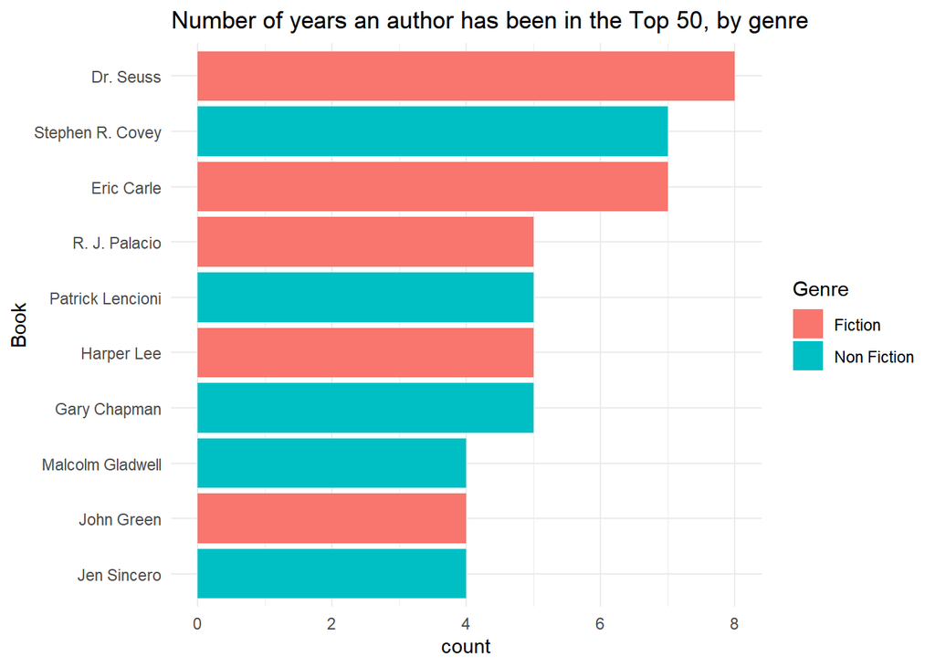

## Ratings

### Most common rating

```
## # A tibble: 12 × 2
##    amz_rating count_r
##         <dbl>   <int>
##  1        3.3       1
##  2        3.9       1
##  3        4         4
##  4        4.1       3
##  5        4.2       4
##  6        4.3       7
##  7        4.4      13
##  8        4.5      12
##  9        4.6      50
## 10        4.7      39
## 11        4.8      48
## 12        4.9      19
```

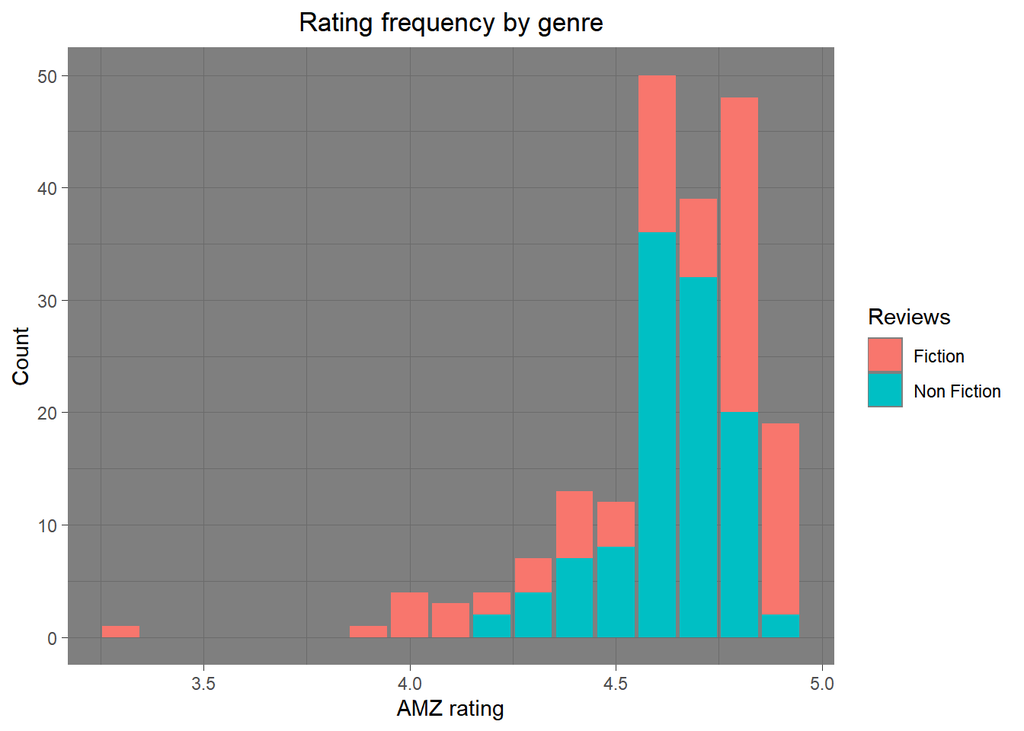

### Rating by year

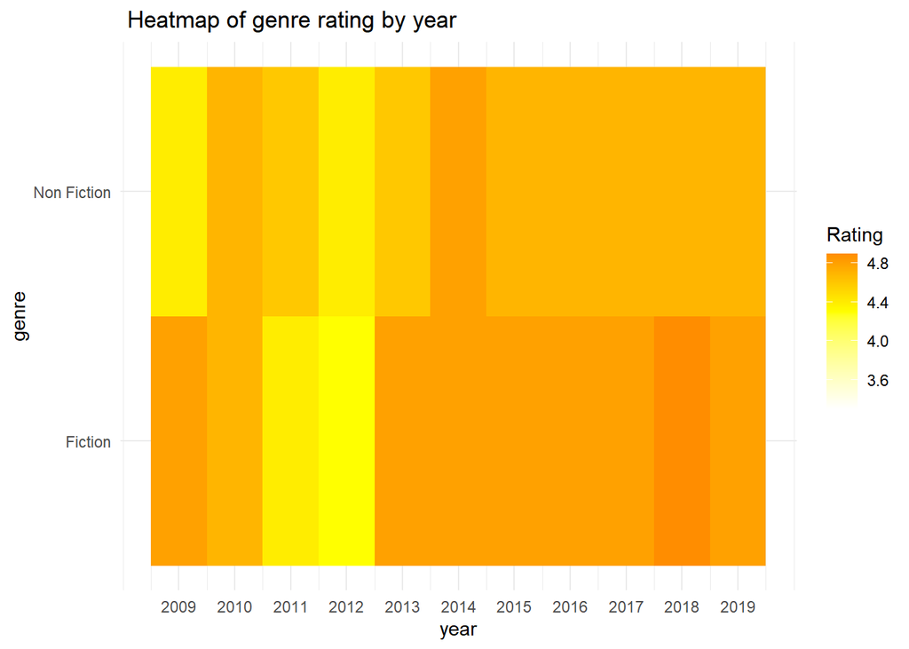

### Amazon ratings vs Goodreads ratings

How are books rated differently by Amazon and Goodreads users?

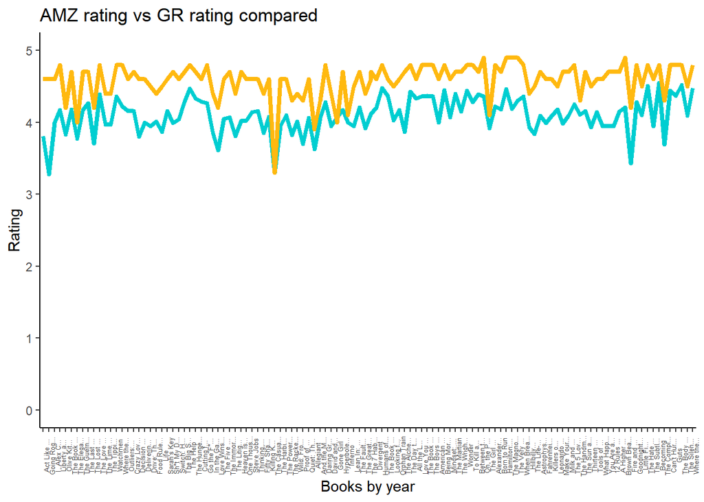

[Aside. Google Spreadsheet does a better-looking graphic in this case]

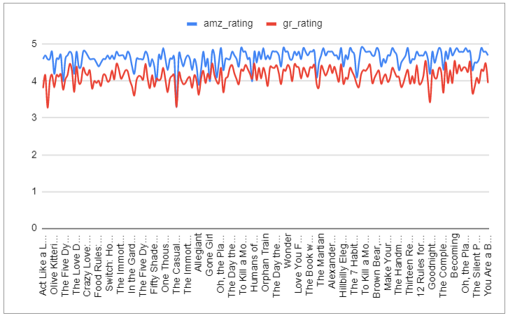

### AMZ vs GR ratings correlation

```
## # A tibble: 1 × 3
##   `Average AMZ rating` `Average GR rating` Correlation
##                  <dbl>               <dbl>       <dbl>
## 1                 4.63                4.13       0.735
```

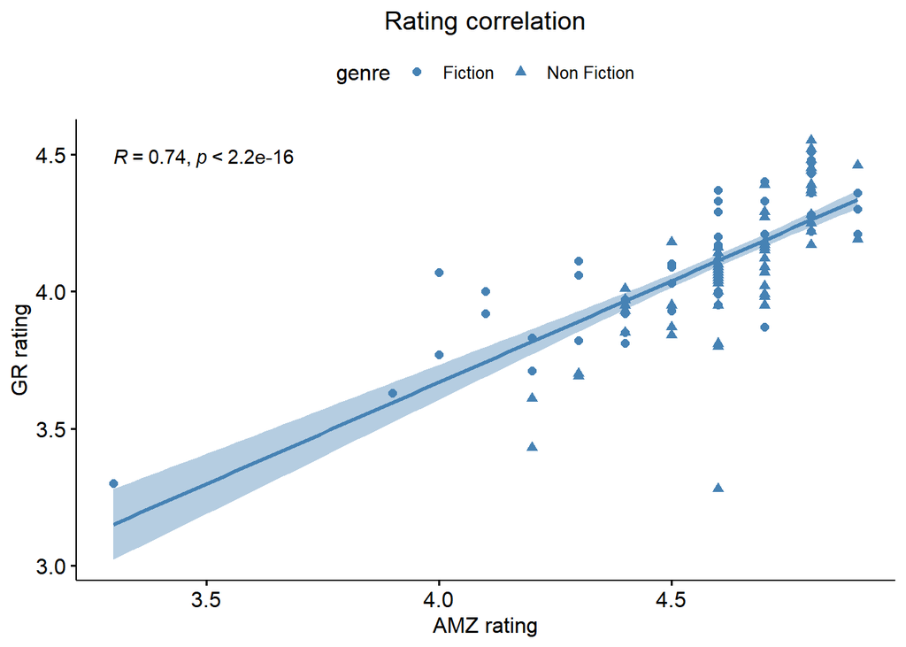

### Observation

While AMZ ratings are higher than the (averaged) GR ratings there’s a strong correlation between the two. For simplicity, following analysis will be done using the original rating (AMZ).

## Prices and number of pages

### Price distribution by year

```
## # A tibble: 11 × 2
##     year Average_price
##    <int>         <dbl>
##  1  2009         15.6
##  2  2010         13.1
##  3  2011         13.9
##  4  2012         14.2
##  5  2013         11.1
##  6  2014         10.8
##  7  2015         10.6
##  8  2016         12.4
##  9  2017         11.1
## 10  2018          8.6
## 11  2019          9.69
```

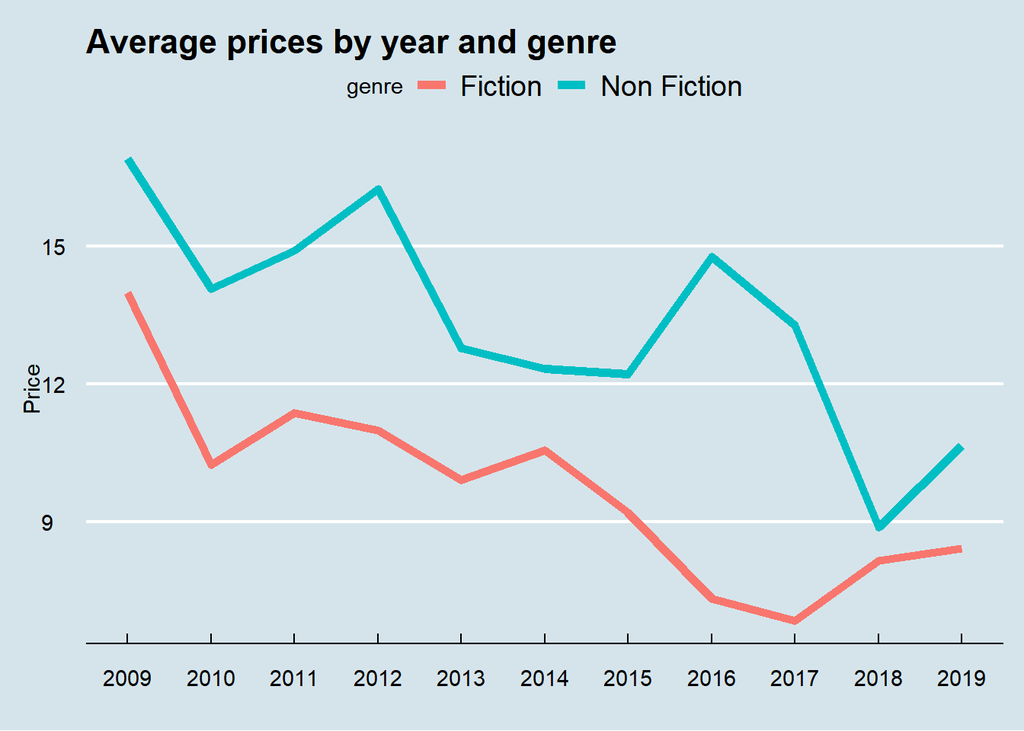

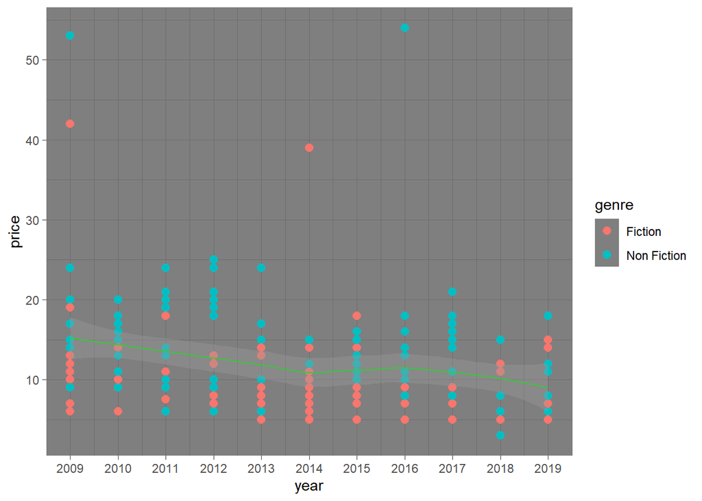

### Price vs rating relationship

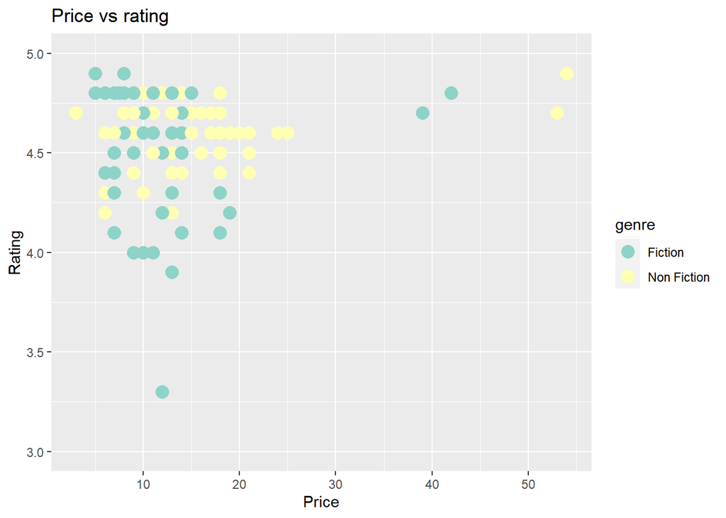

### Price vs number of pages

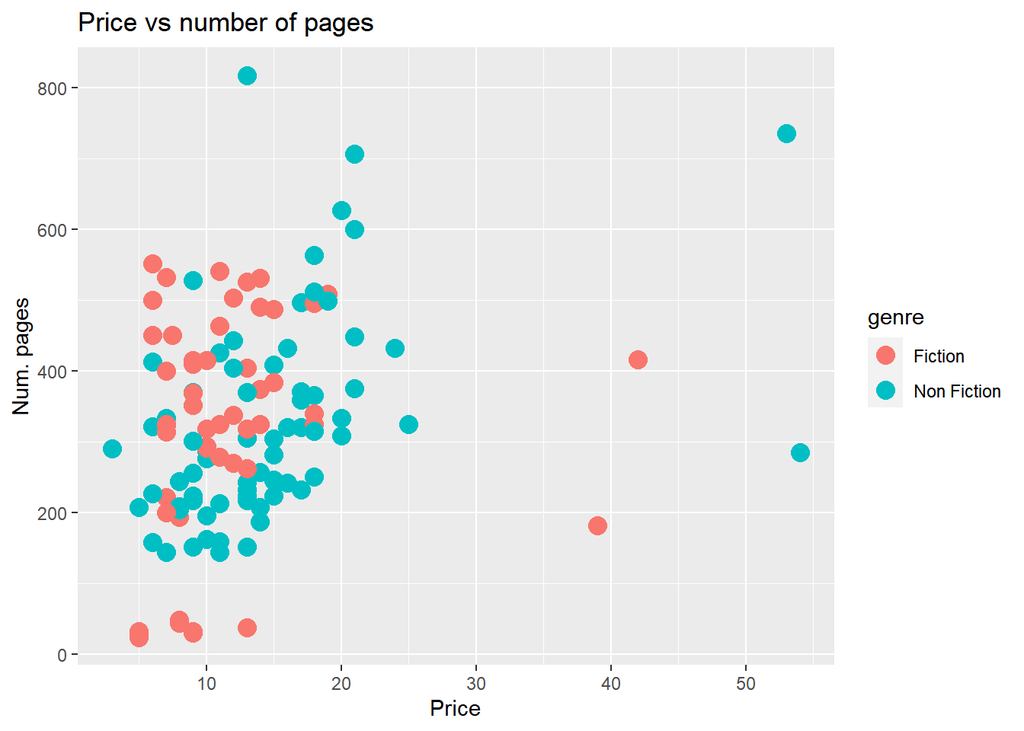

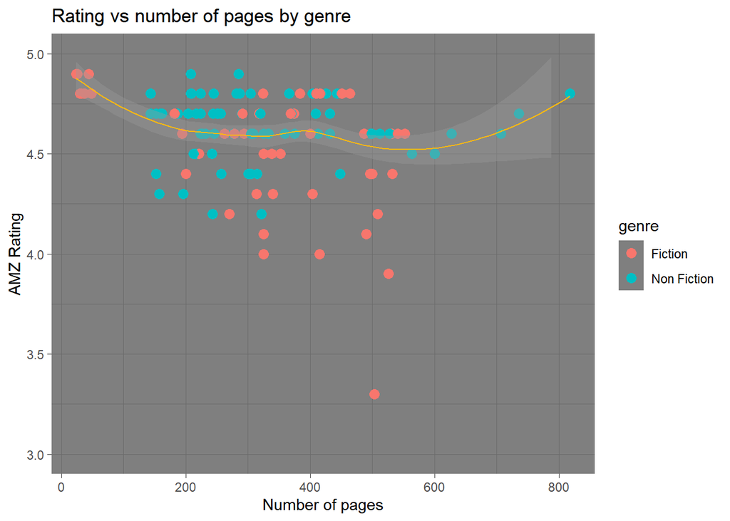

## Reviews

```
## # A tibble: 11 × 3
##     Year `Sum of AMZ reviews` `Sum of GR reviews`
##    <int>                <dbl>               <dbl>
##  1  2009               101479              352390
##  2  2010                96270              409030
##  3  2011               101913              233445
##  4  2012               319519              609345
##  5  2013               372542              923565
##  6  2014               429428             1013200
##  7  2015               405201              559502
##  8  2016               335968              512217
##  9  2017               296885              399526
## 10  2018               293538              312119
## 11  2019               403463              360190
```

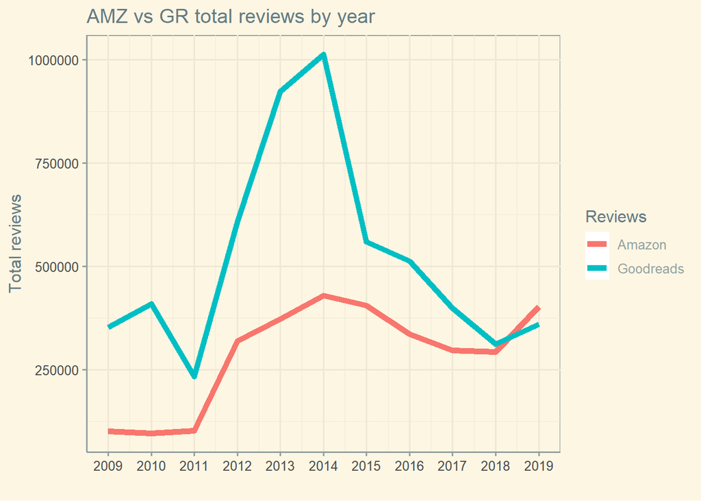

Unlike ratings, total review numbers is very different in both sites: GR users wrote more reviews than AMZ users for the same books - at least prior to 2019. This could be explained by the fact that despite being a subsidiary of AMZ, GR is a social cataloging website and thus users are more interested in sharing their opinion.

```
## # A tibble: 2 × 3
##   genre       `Sum of AMZ reviews` `Sum of GR reviews`
##   <chr>                      <dbl>               <dbl>
## 1 Fiction                  1944031             4304656
## 2 Non Fiction              1212175             1379873
```

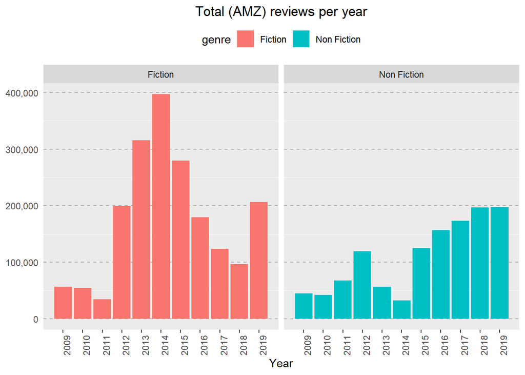

### Observations

Total reviews for Fiction are generally higher (especially in 2014), but slowly declining - until 2019. On the other hand, non fiction reviews were very low, but rising steadily in 2015-2019.

## Genre distribution

```
## # A tibble: 2 × 3
##   genre       count percentage
##   <chr>       <int>      <dbl>
## 1 Fiction        90       44.8
## 2 Non Fiction   111       55.2
```

### Pie chart of total distribution by genre

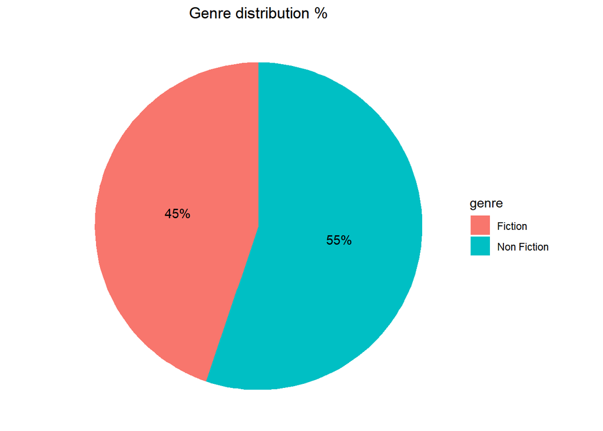

### Observations

55% of bestsellers belong to the general Non fiction genre. When more specific genres are added, Non fiction and fiction still remain the top categories, in that order.

In contrast, Fiction books are more reviewed, as seen above.

### Specific genre distribution %

```
## # A tibble: 24 × 3
##    gr_genre                      count percentage
##    <chr>                         <int>      <dbl>
##  1 Nonfiction                       61      30.4
##  2 Fiction                          22      11.0
##  3 Childrens-Picture Books          16       7.96
##  4 Young Adult                      15       7.46
##  5 Childrens                        12       5.97
##  6 Classics                         11       5.47
##  7 Self Help                        11       5.47
##  8 Business                          7       3.48
##  9 Christian                         7       3.48
## 10 Historical-Historical Fiction     7       3.48
## # … with 14 more rows
```

### Tile chart of total distribution by genre

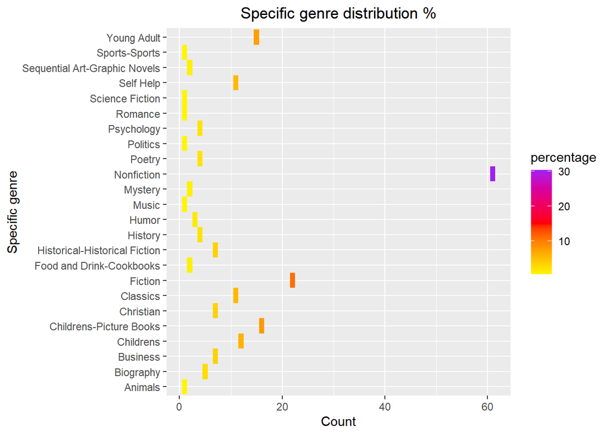

### Heat map of specific genre rating, by year

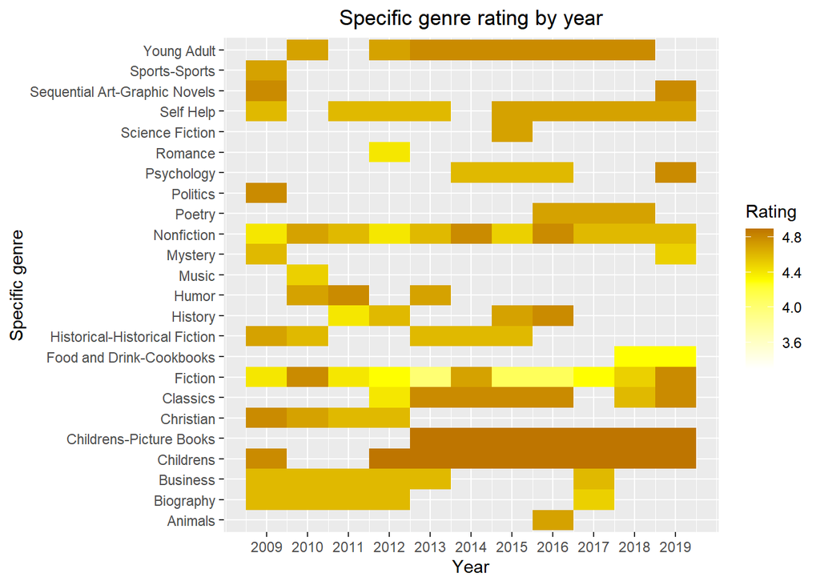

### Specific genre ratings by year

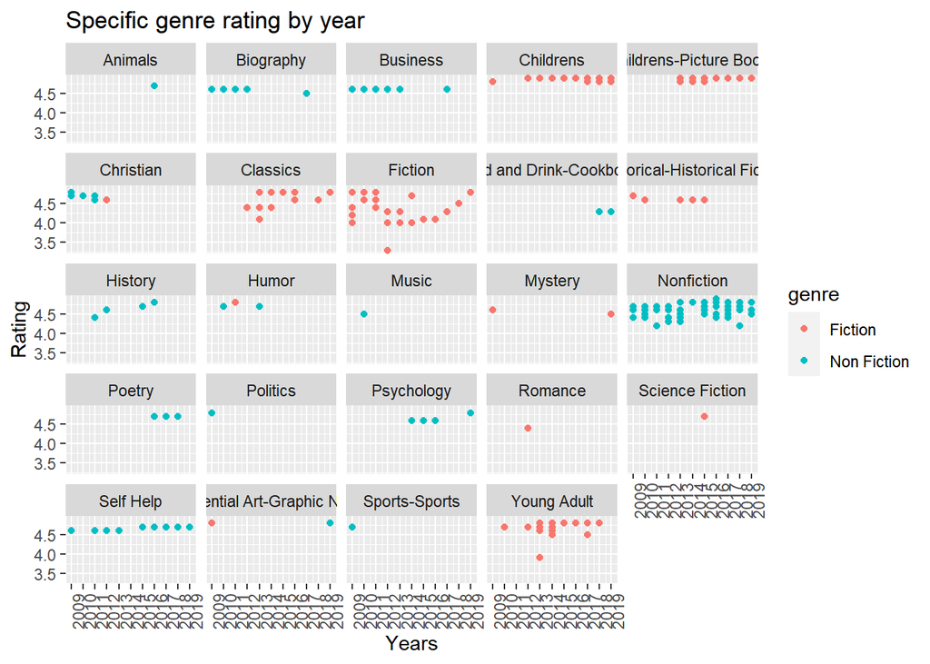

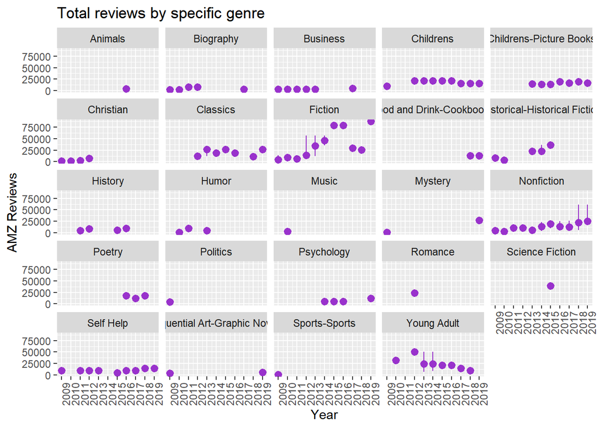

## Points for further analysis

It would be great to analyse if user ratings and purchases are affected by format: ebook, audiobook, paperback/hardcover.

User data (age, sex), and Amazon site version (country) are also not considered here, but they would make interesting points for analysis.

Finally, it’s worth considering how the Covid-19 Pandemic (2019-2022) affected sales, ratings, prices, etc.

[^1]: https://www.kaggle.com/datasets/sootersaalu/amazon-top-50-bestselling-books-2009-2019
[^2]: https://www.kaggle.com/datasets/austinreese/goodreads-books